# Mortality Demographics Presentation

MLauden  
5/28/2018

### Mortality Demographics

This slide set accompanies the associated Shiny web application.

- The dataset is available from the CDC here: https://data.cdc.gov/api/views/w9j2-ggv5/rows.csv?accessType=DOWNLOAD
- Understanding trends and demographic differences in populations helps provide a better understanding of groups that may be under-served by current health care education and availability
- The dataset provides information from 1900 to 2015 on longevity broken down by race and gender
- The program takes a slider as input to control the year range displayed as well as drop down menus for race and sex
- All R expressions are displayed in the presentation per the Review Criteria

### Life Expectancy Demographics by Birth Year

Below is an R expression to evaluate a graph. The actual plot is displayed on the next slide.

```r
mortalityDF<-read.csv("https://data.cdc.gov/api/views/w9j2-ggv5/rows.csv?accessType=DOWNLOAD")
mortalityDFYear<-mortalityDF
library(UsingR)
library(ggplot2)
      p<-ggplot(mortalityDFYear,aes(x=Year, y=Average.Life.Expectancy..Years., color=Race, shape=Sex))+
         geom_jitter()+
         ylab("Average Life Expectancy in Years")+
         theme_bw()
```

### Data Summary

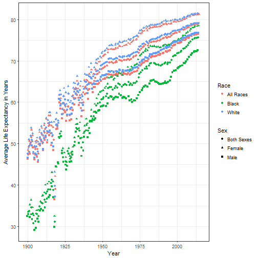

```r
print(p)
```

### Conclusions

The Shiny Web Application presents a simple way to allow end users to explore the CDCs mortality demographic dataset

- The application allows the user to input race, sex, and a time range to limit or expand the data
- The dataset shows increasing average life expectancy for all demographics
- The dataset is very limited and does not provide granularity to account for other racial groups, causes of death, socioeconomic background necessary to gain a full understanding of mortality rates providing an interesting area for further exploratory data analysis